# Homework_9_Markdown

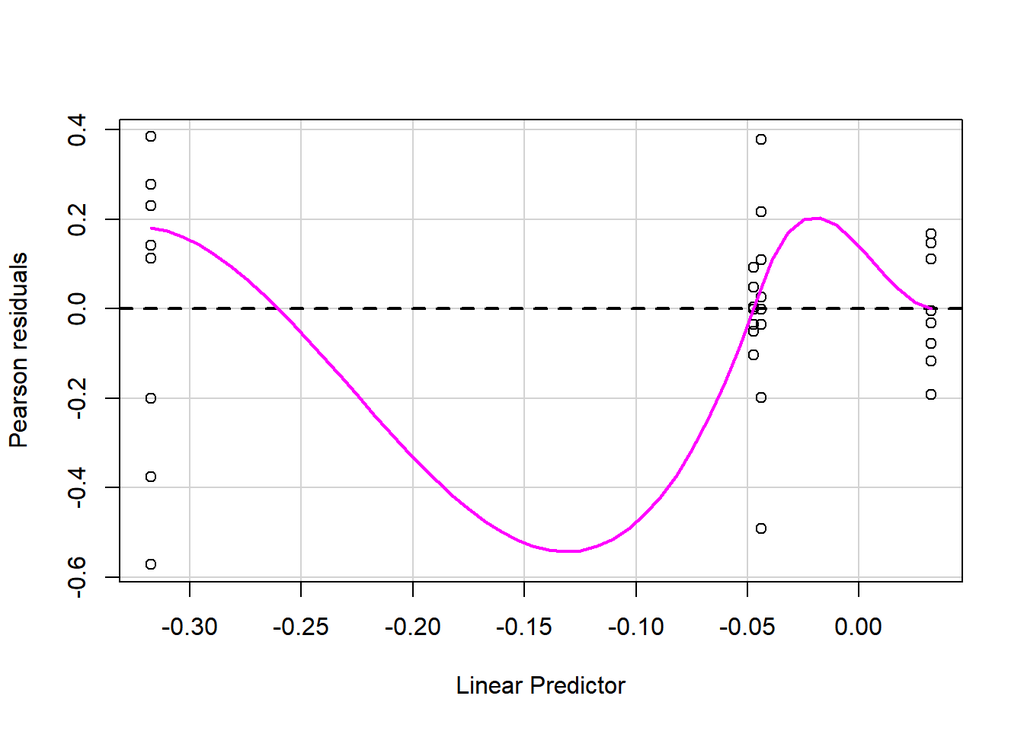

```r
# The first graph is different from the one on https://biol607.github.io/lab/11_anova.html
# Because, the data points are stacked in that graph
# The Q-Q plot is similar

residualPlots(transplant_mle)
```

```r
# There is now sort of a u shaped curve like on the website
# However, the data points are stacked vertically again
# This assumption is not met due to the stacking issue

# Assumptions are not met
```

```
Calculate difference in logit cover (so, logist(initial cover) - logit(final cover)). Logit transformations linearize percent cover data, and are often all that is needed to work percent cover into a linear model. You can use car::logit() for this.
```

```r
library(car)

transplant_mle <- glm((logit(Initial.Cover) - logit(Final.Cover)) ~ Treatment + Caged + Position.On.Block,
                      family = gaussian(link = "identity"),
                      data = transplant)

# Evaluate assumptions ####
# Similar code as: https://biol607.github.io/lab/11_anova.html

par(mfrow=c(2,2))
plot(transplant_mle, which=c(1,2,5))
```

```
## hat values (leverages) are all = 0.125
##  and there are no factor predictors; no plot no. 5
```

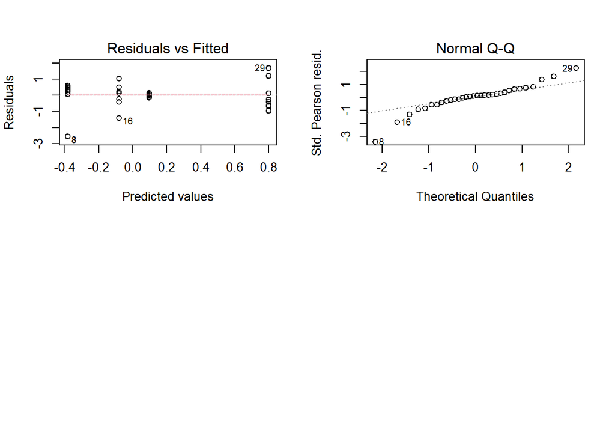

```r
par(mfrow=c(1,1))
```

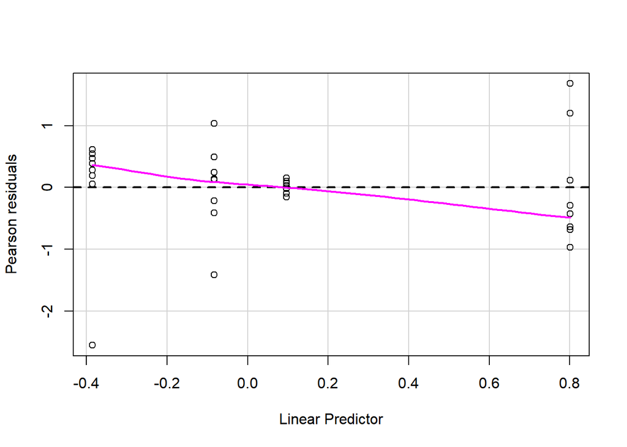

```r
# The first graph is different from the one on https://biol607.github.io/lab/11_anova.html
# Because, the data points are stacked in that graph
# The Q-Q plot is similar

residualPlots(transplant_mle)
```

```r
# This graph is not similar due to the curve and also the data is stacked again

# Assumptions are not met
```

Try all three methods. Which one works so that you can produce valid inference?

I think the one “Incorporate initial cover as a covariate” works best, because it is possible all assumptions are met.

2.4 Great! So, take us home! Using NHST with an alpha of 0.08 (why not), what does this fit model tell you about whether predation matters given how I have described the system? Feel free to replot the data or fit model results if helpful

3. Comparing Means with Covariates

We will wrap up with a model mixing continuous and discrete variables. In this dataset from Scantlebury et al, the authors explored how caste and mass affected the energy level of naked mole rats.